# Compare Gesture

The goal is to compare frequency curves using correlation and root mean square (RMS). Both of these functions take two time series as input. Therefore, it is necessary to convert both the reference pitch curve and gestures from the Gepeto interface into time series data.

References contain information about the stylized pitch curve of a phrase. The stylization is done by Prosogram, an extension to Praat based on a perceptual model detailed by d’Allessandro and Mertens 1995. The stylization is originally generated as PitchTier files by Prosogram but are converted to JSON by Script 3: pitchtierToJSON.

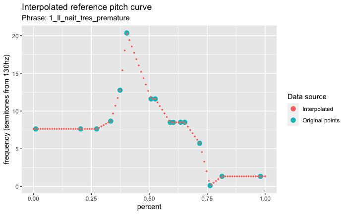

The gestures are collected from non-native speakers enrolled in a class on French rhythm and intonation. Once again, the code just loads the first gesture as a test.

```r
# Load first gesture
path="../data/20_12_15-pilot_gestures/ambiguous/gestures/"
setwd(path)
```

```
The working directory was changed to /Users/xx/Github/GepetoR/data/20_12_15-pilot_gestures/ambiguous/gestures inside a notebook chunk. The working directory will be reset when the chunk is finished running. Use the knitr root.dir option in the setup chunk to change the working directory for notebook…
```

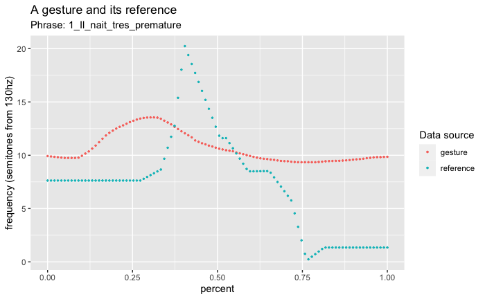

```r
gest_filenames <- dir(pattern="\\.gest$")
name <- gest_filenames[1]
setwd("../../../../notebooks/")
gest_data <- fromJSON(paste0(path, name)) %>% as_tibble()

gest_data_timing_interp <- get_interpolated_data(prep_gest(gest_data), num_samples)


# Plot results
# Dotted is reference
ggplot(data=gest_data_timing_interp, aes(x=index, y=value, color="gesture")) +
      scale_color_discrete(name = "Data source") +
      geom_point(size=0.5) +
      geom_point(data=ref_interp, aes(x=index, y=value, color="reference"), size=0.5) +
      labs(title="A gesture and its reference",
           subtitle=paste("Phrase:",str_split(ref_name, '.json')[[1]][1]),
           y="frequency (semitones from 130hz)",
           x="percent")
```

```r
# Finally, the time series is the values vector
# This will be used in the comparison algorithms
gest_ts <- gest_data_timing_interp$value
```

Now we are ready to quantitatively compare a gesture and its reference. One method is Pearson’s Correlation, which check’s the similarity between the two curves. A value of 1 means identical curves. Note that the mean is subtracted from each curve, so larger gaps between the curves should not decrease the correlation value.

$r = \frac{{}\sum_{i=1}^{n} (x_i - \overline{x})(y_i - \overline{y})} {\sqrt{\sum_{i=1}^{n} (x_i - \overline{x})^2(y_i - \overline{y})^2}}$

Another method is Root Mean Square Error (RMS), which meansures the dissiminlarity between the two curves. The higher the number means there is more difference.

In the 2011 paper evaluating chironomy, both of these measures are weighed by the intensity of the reference audio. For now I’m leaving that weighting out.

```r
cor(ref_ts, gest_ts,  method = "pearson")
```

```
[1] 0.493454
```

```r
rmse(ref_ts, gest_ts)
```

[output not shown]

These numbers for an individual curve are not that informative. Let’s look at some different versions of gestures for each reference.